# Parameters

Lawson et al.

2023-06-16

In this script, we share the code to replicate our parameters.

# 0. File architecture

Create architecture for scripts, visuals and data. Includes `sensitivity_analysis_lq`

# I. Load data

- `dat_p.csv` : price & quantity data from seizures (Source: collated by the Environmental Investigation Agency (EIA) and processed for analysis by authors).
- `totoaba_biomass_catch_20230516.csv` : historical biomass and catch (Source: INAPESCA 2020).
- `w_par.csv`: cost data from for poaching costs (see Supplementary Materials).
- `v_par.csv`: cost data from for aquaculture costs (see Supplementary Materials).

# II. Demand

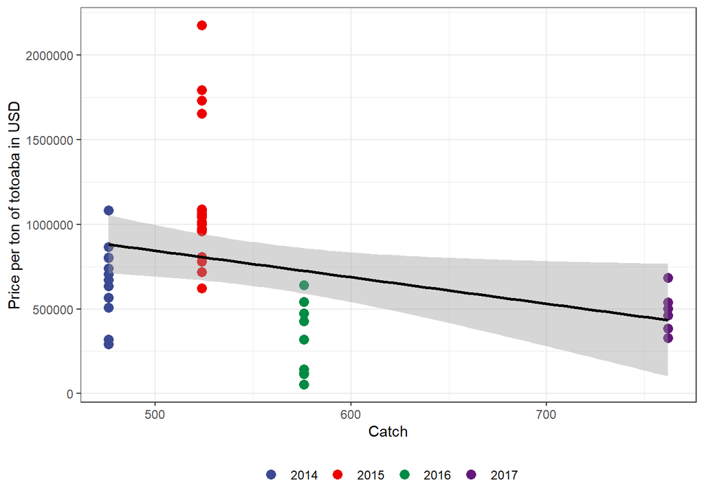

```
##
## Call:
## lm(formula = price_ton_toto ~ c, data = new_dat)
##
## Residuals:
##     Min      1Q  Median      3Q     Max
## -669851 -246794  -50249  201334 1366925
##
## Coefficients:
##             Estimate Std. Error t value Pr(>|t|)
## (Intercept)  1625837     406790   3.997 0.000248 ***
## c              -1564        726  -2.154 0.036890 *
## ---
## Signif. codes:  0 '***' 0.001 '**' 0.01 '*' 0.05 '.' 0.1 ' ' 1
##
## Residual standard error: 431700 on 43 degrees of freedom
## Multiple R-squared:  0.09739,    Adjusted R-squared:  0.0764
## F-statistic:  4.64 on 1 and 43 DF,  p-value: 0.03689
```

# II. Biological parameters

```
##      [,1]           [,2]
## [1,] "K"            "M"
## [2,] "Winfinity"    "Loo"
## [3,] "tmax"         "tm"
## [4,] "Lm"           "Temperature"
## [5,] "ln_margsd"    "rho"
## [6,] "logitbound_h" "ln_r"
```

```
## Closest match: Actinopterygii_Perciformes_Sciaenidae_Totoaba_macdonaldi
```

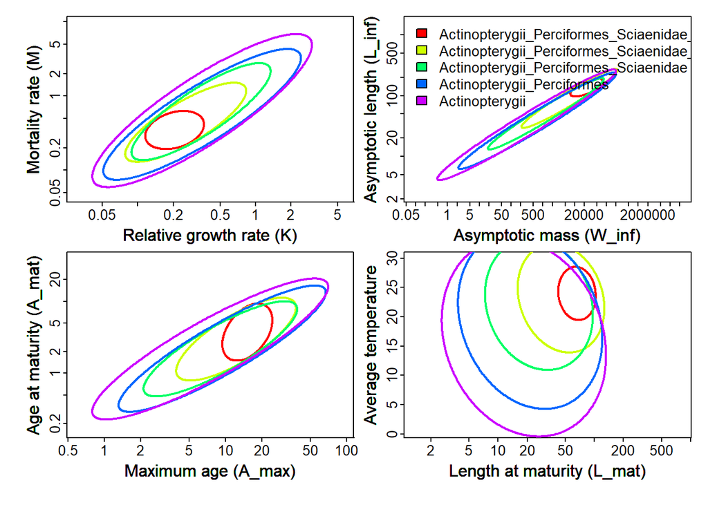

|  | x |
| --- | --- |
| Loo | 4.9184344 |
| K | -1.5830689 |
| Winfinity | 10.0590626 |
| tmax | 2.7171232 |
| tm | 1.3175891 |
| M | -1.0570853 |
| Lm | 4.1868676 |
| Temperature | 24.0087354 |
| ln_var | -2.7136658 |
| rho | 0.6039179 |
| ln_MASPS | -0.1039645 |
| ln_margsd | -1.0414289 |
| h | 0.5263985 |
| logitbound_h | -0.5141059 |
| ln_Fmsy_over_M | -0.0887666 |
| ln_Fmsy | -1.1601266 |
| ln_r | -1.9234144 |
| r | 0.2012827 |
| ln_G | 2.1021294 |
| G | 8.3517745 |

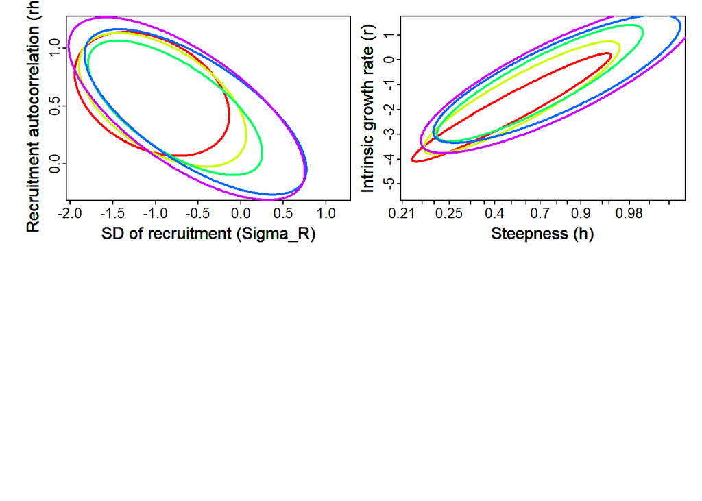

# III. Poaching costs

## A. Build total cost function

### 1. Build average subseasonal costs

First :

- Use `w_par`to reconstruct costs of crew earning, food, fuel, gear
- Compute a cost per trip, with confiscations of gear and vessels
- Compute sub-seasonal average costs

### 2. Total cost from seasonal average cost

We have average cost data, for bins of trips. Here, I estimate a cost function for all the effort levels, that maps the number of trips to their total cost, taking into account different bins.

```
## [1]    0   40  520 1920
```

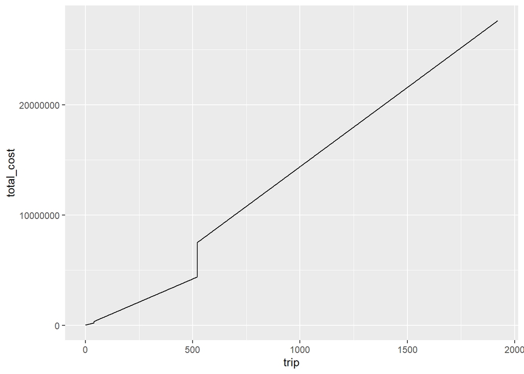

```
## [1] 14386.69
```

The kinky total cost function could be best approximated with a linear term. However, to model the increasing opportunity costs of having more fishermen, it would be nice to have a quadratic term, to forecast the future.

## B. Estimate $W, W_1, W_2$

### 1. Estimate $W$

Find the parameter $W_{quad}$ such that :
$$TotCost(E)=WE^2 \Rightarrow MargCost(E) = 2W_{quad}E$$

And

$$MargCost(E_{hist}) = AvgCost(E_{hist})\Rightarrow W_{quad} =
\frac{W_{avg}}{2E_{hist}}$$

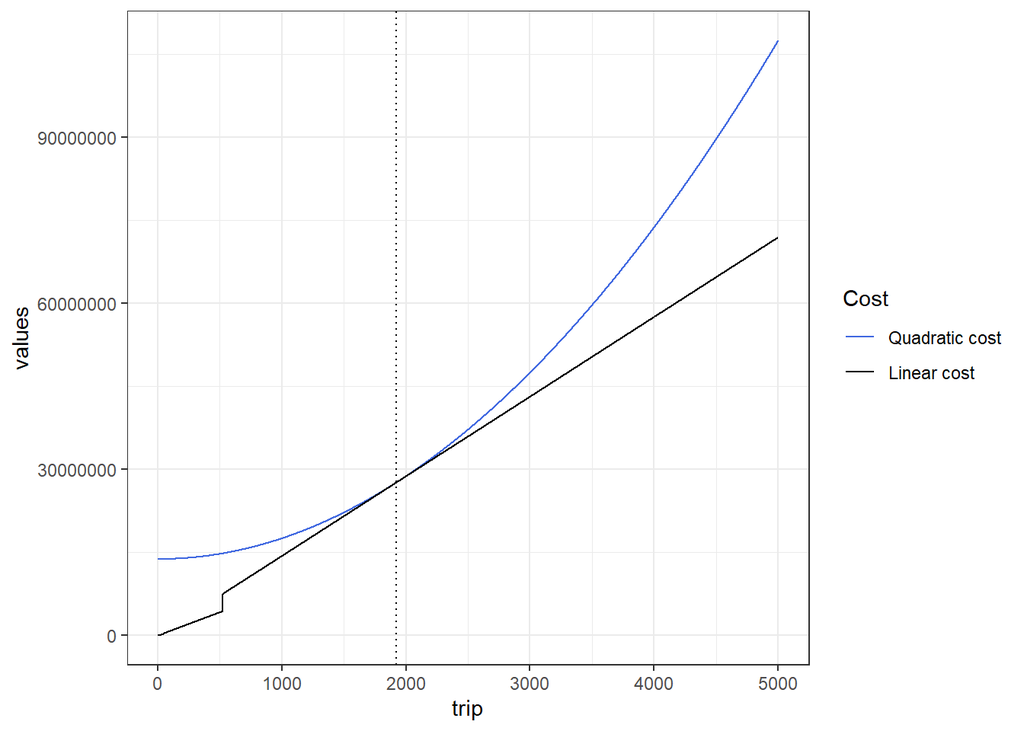

### 2. Estimate $W_1, W_2$

First, find best estimate of modeled cost in a MMSE sense.

```
## [1] "Optimal W1 in an MMSE sense is : 0"
```

```
## [1] "Optimal W2 in an MMSE sense is : 7193.34486399167"
```

| W1 | W2 | diff% | mse |
| --- | --- | --- | --- |
| 0 | 0.0000000 | 0.0000000 | 0 |
| 11000 | 0.8819504 | 11.7702188 | 30647515448353752 |
| 11400 | 0.7777838 | 10.3800450 | 24033220500031512 |
| 11800 | 0.6736171 | 8.9898711 | 18274620332517136 |
| 12200 | 0.5694504 | 7.5996973 | 13371714945810632 |
| 12600 | 0.4652838 | 6.2095234 | 9324504339911994 |
| 13000 | 0.3611171 | 4.8193495 | 6132988514821220 |
| 13400 | 0.2569504 | 3.4291757 | 3797167470538315 |
| 13800 | 0.1527838 | 2.0390018 | 2317041207063276 |
| 14200 | 0.0486171 | 0.6488279 | 1692609724396104 |

Here, I keep as the baseline specification the first value with low difference with cost

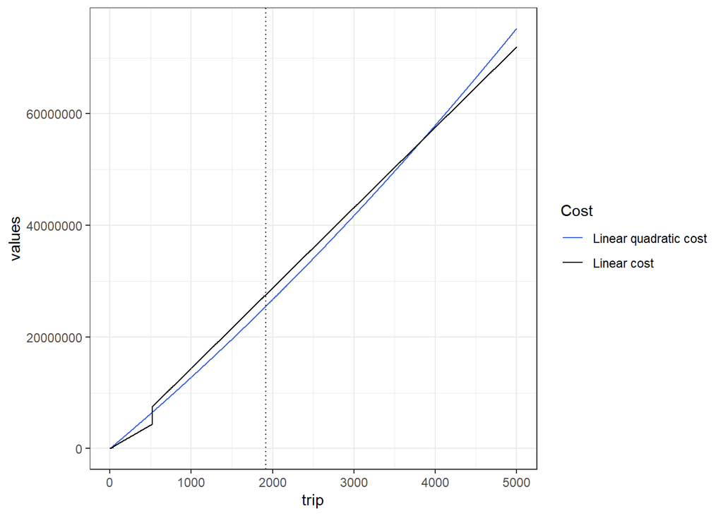

### 3. Export data and sources for W

Export data for $W$ and the corresponding model parameters for the quadratic model ($W$) and linear-quadratic model ($W_1$ and $W_2$)

# IV. Trading costs

We use `c=` 0 as trading costs.

# V. Farming costs

At 4.5 years under farming conditions, a totoaba should have a 416.96g swim bladder. At 5 years under farming conditions, a totoaba should have a 529.78 g swim bladder

# VI. Save calibration data

| params | value | concept | units |
| --- | --- | --- | --- |
| alpha | 1625836.98 | Demand model : intercept | USD |
| beta | 1563.75 | Demand model : coefficient | USD/metric ton of biomass |
| r | 0.20 | Intrinsic growth rate | unitless |
| k | 20226.00 | Carrying capacity (in metric tons) | metric tons of biomass |
| sigma | 0.00 | Catchability | % of biomass/vessel trip |
| avg_cost | 14386.69 | Average cost per vessel trip at historical value | USD/vessel trip |
| W_high | 3.75 | Quadratic cost parameter - Quadratic cost function | USD vessel trip$^{-2}$ |
| fixed_cost | 13811222.14 | Fixed cost - Quadratic cost function | USD |
| W1 | 12200.00 | Linear cost parameter - Linear quadratic cost function | USD/vessel trip |
| W2 | 0.57 | Quadratic cost parameter - Linear quadratic cost function | USD vessel trip$^{-2}$ |
| age | 4.50 | Age of farmed totoaba | Years |
| gamma | 1354.25 | Demand model : substitutable good coefficient | USD/metric ton of biomass |
| v | 89929.92 | Unit cost of farming | USD/metric ton of biomass |
| i_r | 0.10 | Interest rate | % |
| c | 0.00 | Unit cost of trading | USD/ metric ton of biomass |